# find_diff_markers

## Find differentially chromatin accessible features

This pipeline helps identify genes with differential chromatin accessibility across different cell clusters. It returns a specified number of top genes (**-top_gene_num**) that exhibit the most differential chromatin accessibility in each cluster, compared to other clusters, visualized using UMAP. Additionally, it generates a TXT file listing the differentially accessible genes for each cell cluster.

The pipeline ranks the genes according to a user-defined method (**-normT**), with options including **mean.dif**, **prop.dif**, or **adj.dif**.

- **mean.dif** ranks genes based on top-to-bottom chromatin accessibility across clusters, calculated by the mean imputed chromatin accessibility values across all cells.
- **prop.dif** ranks genes by the proportion of cells showing chromatin accessibility for each gene.
- **adj.dif** ranks genes based on the product of **mean.dif** and **prop.dif**.

**Inputs** (Required):  
1. **-script_dir** (a script directory downloaded from GitHub: Socrates2/utils/input_other_required_scripts_dir)  
2. **-soc_obj** (The *.atac.soc.qs2 object obtained from the [Prepare gene accessibility](http://htmlpreview.github.io/?https://github.com/yanhaidong1/Socrates2/blob/main/vignettes/prepare_gene_accessibility.html) step)  
3. **-o output_dir** (mkdir output_dir)

**Optional parameters:**  
1. **-prop_threshold 0.01** (Select genes that meet the minimum proportion threshold, which is determined by the proportion of cells exhibiting chromatin accessibility for each gene. Default: 0.01.)  
2. **-top_gene_num 5** (Decide the number of genes will be plotted per cluster. Default: 5.)  
3. **-normT mean.dif** (Determine the ranking method (mean.dif/prop.dif/adj.dif) for ordering genes based on top-to-bottom chromatin accessibility across different clusters. Default: mean.dif.)  
4. **-prefix output** (Specify a prefix name for the final output file. Default: output.)

**Outputs:**  
1. *.atac.soc.qs2  
2. *.top5genes.rank_difs.txt  
3. *.denovo.pdf

**Running**:

```bash
python Socrates2/utils/find_diff_markers.py
-script_dir Socrates2/utils/input_other_required_scripts_dir
-o output_dir
-soc_obj /Path/to/*.atac.soc.qs2
```

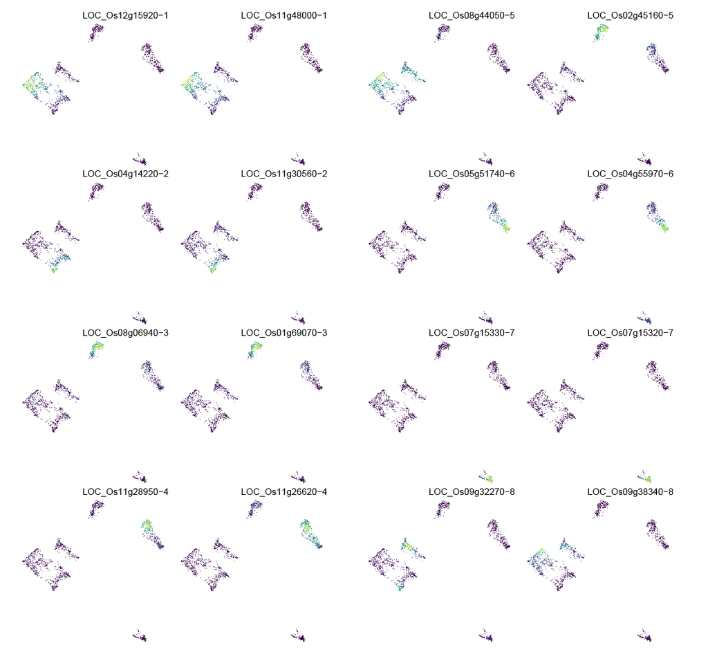

Figure 1: example of UMAP plotting from *.denovo.pdf plotting. The title of each subplot combines the gene ID and the cluster ID. For instance, **LOC_Os12g15920-1** indicates the gene ID (**LOC_Os12g15920**) and the corresponding cluster ID (**1**).